# Prior ST9 Exams

C. Lau

September 26, 2016

## 2016 April

[2016 April Exam](https://www.actuaries.org.uk/documents/subject-st9-enterprise-risk-management-exam-paper-april-2016)

[2016 April Examiners’ Report](https://www.actuaries.org.uk/documents/subject-st9-enterprise-risk-management-examiners-report-april-2016)

### Question 1

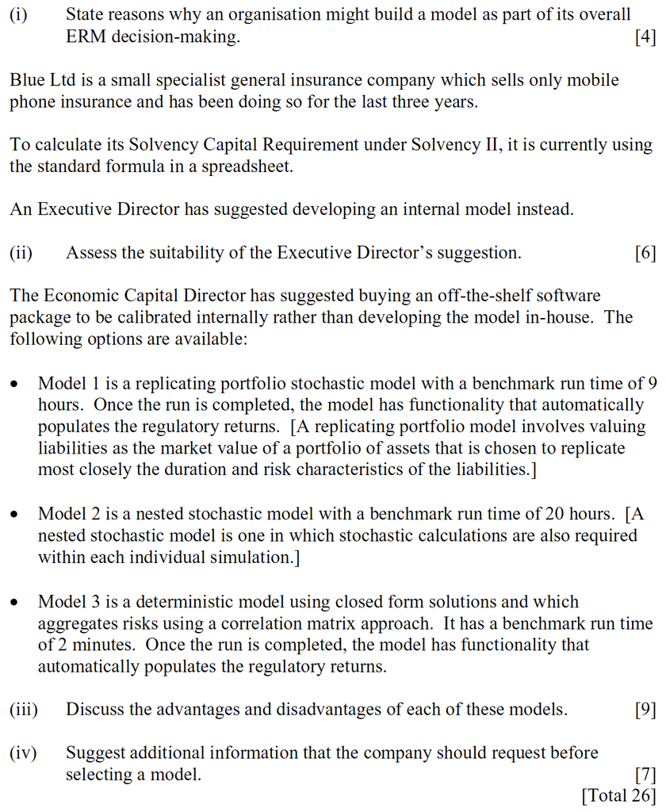

#### Q1.i

Reasons to build an internal model for ERM

- Module 30 Section “Internal Capital Models”
- Module 21 Section “Model Development”

#### Q1.ii

Pros and cons of using standard formula vs internal model for SII

- Module 30 Section “Internal vs Generic Models”
- Key to focus is on the small size and niche risk of the company
- Make sure to discuss both sides

#### Q1.iii

Selection of models between 3 options

Some key points:

- Model 1:
  - Runtime okay
  - Less human error
  - Some approximation
  - Appropriate matching assets might be hard to find
- Model 2:
  - Least approximation
  - Hard to calibrate (due to high number of real world scenarios needed)
  - Long run time
  - Too complex hard to test
- Model 3:
  - Greatest level of simplification

#### Q1.iv

Additional information on the software to request

- A bunch of stuff easy

### Question 2

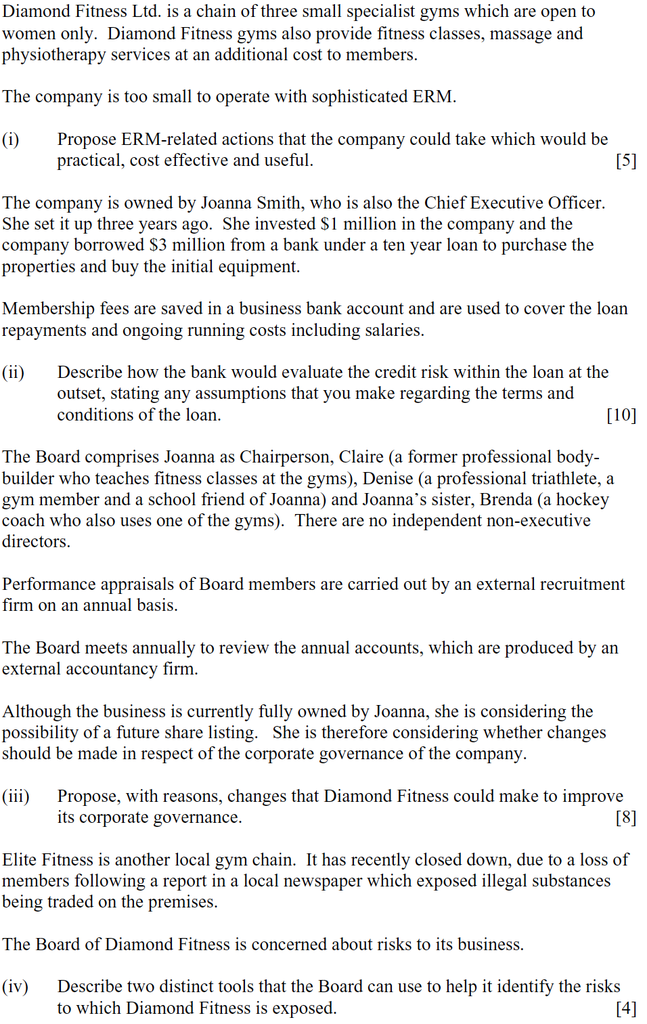

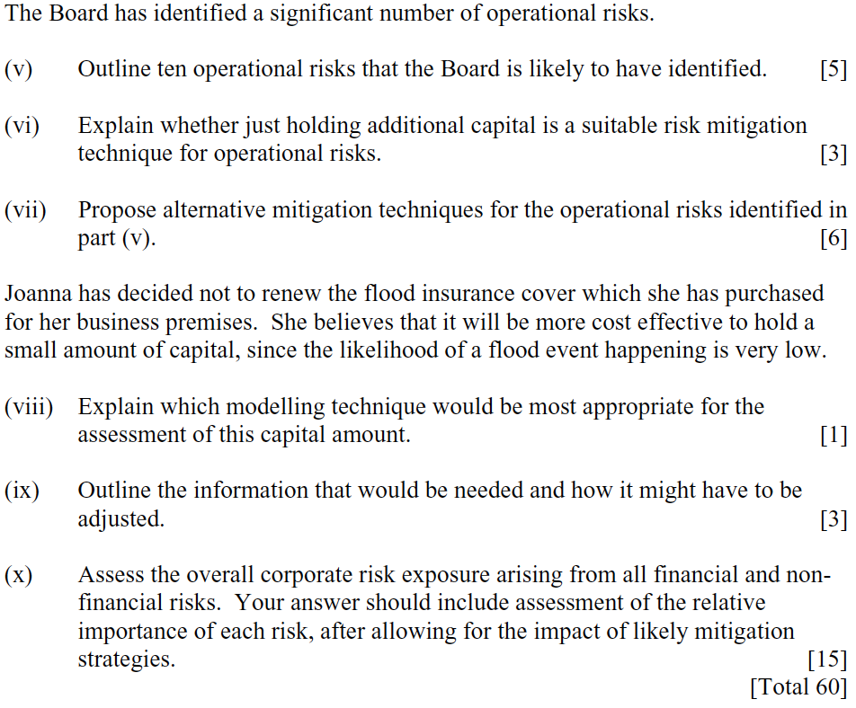

#### Q2.i

Propose practical cost effective ERM activities

- Make sure we’re not just proposing mitigation activities
- Key is on the early steps of the ERM process and more focus on the governance
  - Identify
  - Risk register
  - Risk appetite and tolerance statement
  - RMC and have meetings and risk reports
  - Appoint risk manager
- Module 13 Section “Risk Identification and Assessment Process”
- Module 9 Section “Risk Management Policy”
  - Risk appetite, risk tolerance, risk limits
- Module 10 Section “Risk Reporting”
  - Not as much from here, mostly just report

#### Q2.ii

How bank would evaluate the credit risk of the company

- Should be mostly from Module 23 and 28
  - Module 28 Section: `Credit Granting`, `Underwriting`, `Due Diligence`
- List out the assumptions, how to access probability of default and loss given default
- Key is to have a wide range of ideas
- PD
  - Assess this for key possible reasons for default
  - 1 reason would be due to non payment
  - Another reason could be macro driven (e.g. property value < loan principal)
- LGD
  - Walk through what the LGD would be

#### Q2.iii

Improvement on corporate governance

- Module 4, 11, 12 (maybe 8 and 9)
- Some key themes
  - BoD structure
    - NEDs and its benefits
  - Incentivise the BoD
  - Expand shareholders
  - Board committees
  - Audit structure

#### Q2.iv

Risk identification tools

- Module 3
  - Section “Risk Identification Tools”

#### Q2.v

10 potential op risk

- List a bunch of op risk…

#### Q2.vi

Whether holding additiona capital is a suitable risk mitigation technique for op-risk

- Modeul 29 (maybe 24)

#### Q2.vii

Alternative mitigation techniques for the op-risk in v

- Modeul 29 (maybe 24)

#### Q2.viii

Modeling for flood risk

- EVT

#### Q2.ix

Information needed for modeling flood risk

- Module 20, 15
- Amount of data, for freq and sev
- Repair cost and expert judgement (for trends and changes)

#### Q2.x

Overall corporate risk exposure and importance of each risk after allowing for the impact of likely mitigation strategies

- Module 13
- Use Categorization technique to rank the risk
- State what are the objectives used to judge the risk
- Define what high risk is
- Categories of risk:
  - Operational

  list out the rating for freq and sev and any mitigations
  - Financial
  - Customer demand
  - Other
- Other considerations
  - Correlations
  - Company’s mitigation process
- Conclusions

### Question 3

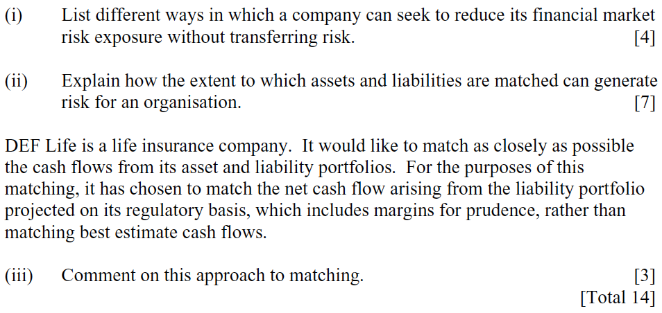

#### Q3.i

Ways to reduce financial market risk exposure without risk transfer

- Module 26, 27, 28
- Avoidance
- Diversification
- ALM
- Internal control

#### Q3.ii

ALM risk

- Module 22, 27

#### Q3.iii

Cashflow matching

- Module 22, 27